# 📉 Customer Churn Prediction — Telco Dataset

**Goal:** Predict which customers are likely to stop using the service (churn), so the business can proactively retain them.

**Dataset:** IBM Telco Customer Churn — 7,043 customers, 21 features (demographics, account info, services subscribed).

**Approach:**

1. Exploratory Data Analysis (EDA) — understand churn patterns
2. Data preprocessing — encoding, scaling, train/test split
3. Model training — Logistic Regression, Random Forest, XGBoost
4. Evaluation — Accuracy, Precision, Recall, F1, ROC-AUC
5. Explainability — feature importance & SHAP values

```python
import warnings
warnings.filterwarnings("ignore")

import pandas as pd
import numpy as np
import matplotlib.pyplot as plt
import seaborn as sns

from sklearn.model_selection import train_test_split
from sklearn.preprocessing import StandardScaler, LabelEncoder
from sklearn.linear_model import LogisticRegression
from sklearn.ensemble import RandomForestClassifier
from sklearn.metrics import (
    accuracy_score, recall_score, precision_score, f1_score,
    roc_auc_score, roc_curve, confusion_matrix, classification_report
)
import xgboost as xgb
import shap

sns.set_style("whitegrid")
plt.rcParams["figure.dpi"] = 100
```

## 1. Load & Clean the Data

```python
df = pd.read_csv("../data/Telco-Customer-Churn.csv")
print("Shape:", df.shape)
df.head()
```

```
Shape: (7043, 21)
```

|  | customerID | gender | SeniorCitizen | Partner | Dependents | tenure | PhoneService | MultipleLines | InternetService | OnlineSecurity | ... | DeviceProtection | TechSupport | StreamingTV | StreamingMovies | Contract | PaperlessBilling | PaymentMethod | MonthlyCharges | TotalCharges | Churn |
| --- | --- | --- | --- | --- | --- | --- | --- | --- | --- | --- | --- | --- | --- | --- | --- | --- | --- | --- | --- | --- | --- |
| 0 | 7590-VHVEG | Female | 0 | Yes | No | 1 | No | No phone service | DSL | No | ... | No | No | No | No | Month-to-month | Yes | Electronic check | 29.85 | 29.85 | No |
| 1 | 5575-GNVDE | Male | 0 | No | No | 34 | Yes | No | DSL | Yes | ... | Yes | No | No | No | One year | No | Mailed check | 56.95 | 1889.5 | No |
| 2 | 3668-QPYBK | Male | 0 | No | No | 2 | Yes | No | DSL | Yes | ... | No | No | No | No | Month-to-month | Yes | Mailed check | 53.85 | 108.15 | Yes |
| 3 | 7795-CFOCW | Male | 0 | No | No | 45 | No | No phone service | DSL | Yes | ... | Yes | Yes | No | No | One year | No | Bank transfer (automatic) | 42.30 | 1840.75 | No |
| 4 | 9237-HQITU | Female | 0 | No | No | 2 | Yes | No | Fiber optic | No | ... | No | No | No | No | Month-to-month | Yes | Electronic check | 70.70 | 151.65 | Yes |

5 rows × 21 columns

```python
# TotalCharges is stored as text and has blank values for brand-new customers (tenure = 0)
df["TotalCharges"] = pd.to_numeric(df["TotalCharges"], errors="coerce")
df["TotalCharges"] = df["TotalCharges"].fillna(df["MonthlyCharges"])

# Drop ID column - not predictive
df.drop(columns=["customerID"], inplace=True)

# Encode target
df["Churn"] = df["Churn"].map({"Yes": 1, "No": 0})

df.isnull().sum().sum(), df.shape
```

```
(np.int64(0), (7043, 20))
```

## 2. Exploratory Data Analysis (EDA)

Key questions we want to answer:

- What % of customers churn overall?
- Does contract type affect churn?
- Does tenure (how long they've been a customer) affect churn?
- Do monthly charges affect churn?

```
Overall churn rate: 26.54%
```

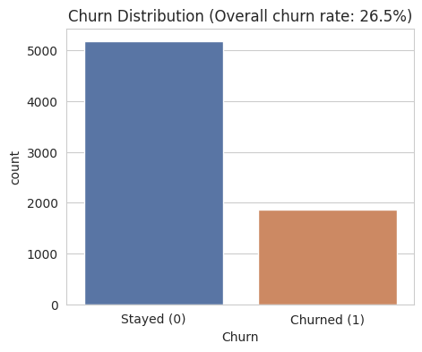

```python
churn_rate = df["Churn"].mean() * 100
print(f"Overall churn rate: {churn_rate:.2f}%")

plt.figure(figsize=(5,4))
ax = sns.countplot(x="Churn", data=df, palette=["#4C72B0", "#DD8452"])
ax.set_xticklabels(["Stayed (0)", "Churned (1)"])
plt.title(f"Churn Distribution (Overall churn rate: {churn_rate:.1f}%)")
plt.show()
```

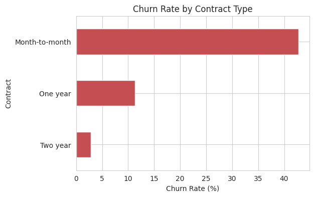

```
Contract
Two year           2.831858
One year          11.269518
Month-to-month    42.709677
Name: Churn, dtype: float64
```

```python
plt.figure(figsize=(6,4))
contract_churn = df.groupby("Contract")["Churn"].mean().sort_values() * 100
contract_churn.plot(kind="barh", color="#C44E52")
plt.xlabel("Churn Rate (%)")
plt.title("Churn Rate by Contract Type")
plt.show()
contract_churn
```

**Insight:** Month-to-month customers churn far more than customers on 1 or 2-year contracts — this is expected since they have no lock-in and can leave anytime.

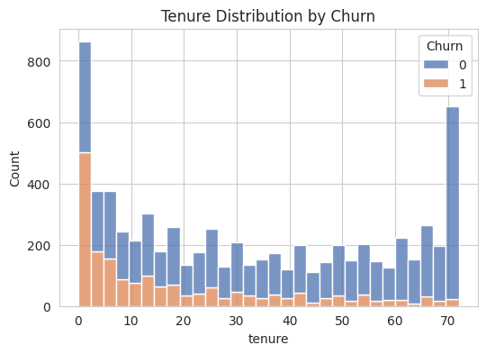

```
Avg tenure - churned: 18.0
Avg tenure - retained: 37.6
```

```python
plt.figure(figsize=(6,4))
sns.histplot(data=df, x="tenure", hue="Churn", bins=30, multiple="stack", palette=["#4C72B0", "#DD8452"])
plt.title("Tenure Distribution by Churn")
plt.show()

print("Avg tenure - churned:", df[df.Churn==1]["tenure"].mean().round(1))
print("Avg tenure - retained:", df[df.Churn==0]["tenure"].mean().round(1))
```

**Insight:** Customers who churn tend to have much shorter tenure — the first few months are the highest-risk period for losing a customer.

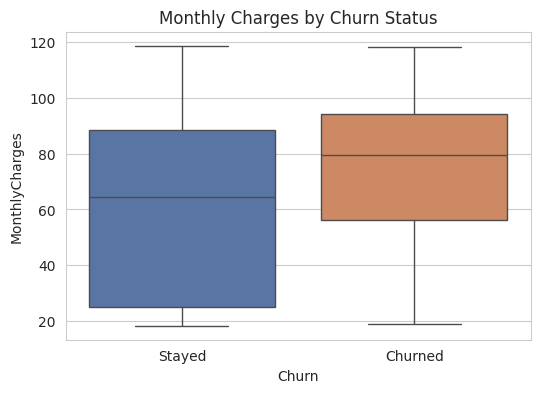

```python
plt.figure(figsize=(6,4))
sns.boxplot(x="Churn", y="MonthlyCharges", data=df, palette=["#4C72B0", "#DD8452"])
plt.xticks([0,1], ["Stayed", "Churned"])
plt.title("Monthly Charges by Churn Status")
plt.show()
```

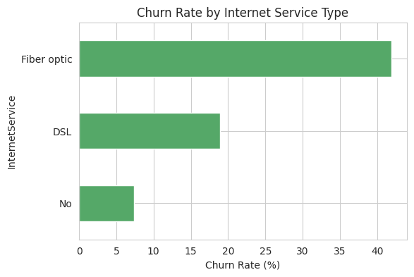

```
InternetService
No              7.404980
DSL            18.959108
Fiber optic    41.892765
Name: Churn, dtype: float64
```

```python
plt.figure(figsize=(6,4))
internet_churn = df.groupby("InternetService")["Churn"].mean().sort_values() * 100
internet_churn.plot(kind="barh", color="#55A868")
plt.xlabel("Churn Rate (%)")
plt.title("Churn Rate by Internet Service Type")
plt.show()
internet_churn
```

**Insight:** Fiber optic customers churn more than DSL customers — possibly due to higher pricing or service issues, worth investigating further with the business team.

## 3. Preprocessing

```python
df_enc = df.copy()
cat_cols = df_enc.select_dtypes(include="object").columns.tolist()
print("Categorical columns to encode:", cat_cols)

encoders = {}
for col in cat_cols:
    le = LabelEncoder()
    df_enc[col] = le.fit_transform(df_enc[col])
    encoders[col] = le

X = df_enc.drop(columns=["Churn"])
y = df_enc["Churn"]

X_train, X_test, y_train, y_test = train_test_split(
    X, y, test_size=0.2, random_state=42, stratify=y
)

scaler = StandardScaler()
X_train_scaled = pd.DataFrame(scaler.fit_transform(X_train), columns=X.columns, index=X_train.index)
X_test_scaled = pd.DataFrame(scaler.transform(X_test), columns=X.columns, index=X_test.index)

print("Train shape:", X_train.shape, " Test shape:", X_test.shape)
```

```
Categorical columns to encode: ['gender', 'Partner', 'Dependents', 'PhoneService', 'MultipleLines', 'InternetService', 'OnlineSecurity', 'OnlineBackup', 'DeviceProtection', 'TechSupport', 'StreamingTV', 'StreamingMovies', 'Contract', 'PaperlessBilling', 'PaymentMethod']
```

```
Train shape: (5634, 19)  Test shape: (1409, 19)
```

## 4. Model Training

We train 3 classification models and compare them:

- **Logistic Regression** — simple, interpretable baseline
- **Random Forest** — handles non-linearity, robust to outliers
- **XGBoost** — gradient boosting, usually strongest performer on tabular data

All models use `class_weight`/`scale_pos_weight` to handle the churn class imbalance (~26% churn vs 74% retained).

```python
results = {}
roc_data = {}

def evaluate(name, model, X_te, y_te):
    y_pred = model.predict(X_te)
    y_prob = model.predict_proba(X_te)[:, 1]
    metrics = {
        "accuracy": accuracy_score(y_te, y_pred),
        "precision": precision_score(y_te, y_pred),
        "recall": recall_score(y_te, y_pred),
        "f1_score": f1_score(y_te, y_pred),
        "roc_auc": roc_auc_score(y_te, y_prob),
    }
    results[name] = metrics
    roc_data[name] = y_prob

    cm = confusion_matrix(y_te, y_pred)
    plt.figure(figsize=(4,3.5))
    sns.heatmap(cm, annot=True, fmt="d", cmap="Blues",
                xticklabels=["No Churn","Churn"], yticklabels=["No Churn","Churn"])
    plt.title(f"Confusion Matrix - {name}")
    plt.ylabel("Actual"); plt.xlabel("Predicted")
    plt.show()

    print(classification_report(y_te, y_pred, target_names=["No Churn","Churn"]))
    return metrics
```

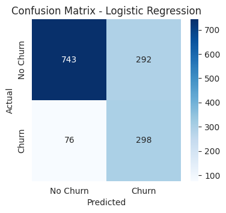

```
              precision    recall  f1-score   support

    No Churn       0.91      0.72      0.80      1035
       Churn       0.51      0.80      0.62       374

    accuracy                           0.74      1409
   macro avg       0.71      0.76      0.71      1409
weighted avg       0.80      0.74      0.75      1409
```

```
{'accuracy': 0.7388218594748048,
 'precision': 0.5050847457627119,
 'recall': 0.7967914438502673,
 'f1_score': 0.6182572614107884,
 'roc_auc': 0.8397840295538506}
```

```python
# Logistic Regression
log_reg = LogisticRegression(max_iter=1000, class_weight="balanced", random_state=42)
log_reg.fit(X_train_scaled, y_train)
evaluate("Logistic Regression", log_reg, X_test_scaled, y_test)
```

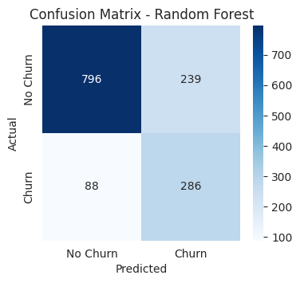

```
              precision    recall  f1-score   support

    No Churn       0.90      0.77      0.83      1035
       Churn       0.54      0.76      0.64       374

    accuracy                           0.77      1409
   macro avg       0.72      0.77      0.73      1409
weighted avg       0.81      0.77      0.78      1409
```

```
{'accuracy': 0.7679205110007097,
 'precision': 0.5447619047619048,
 'recall': 0.7647058823529411,
 'f1_score': 0.6362625139043382,
 'roc_auc': 0.8421387790953008}
```

```python
# Random Forest
rf = RandomForestClassifier(n_estimators=300, max_depth=8, class_weight="balanced", random_state=42, n_jobs=-1)
rf.fit(X_train, y_train)
evaluate("Random Forest", rf, X_test, y_test)
```

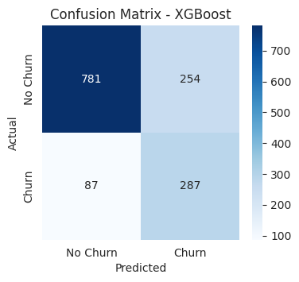

```
              precision    recall  f1-score   support

    No Churn       0.90      0.75      0.82      1035
       Churn       0.53      0.77      0.63       374

    accuracy                           0.76      1409
   macro avg       0.72      0.76      0.72      1409
weighted avg       0.80      0.76      0.77      1409
```

```
{'accuracy': 0.7579843860894251,
 'precision': 0.5304990757855823,
 'recall': 0.767379679144385,
 'f1_score': 0.6273224043715847,
 'roc_auc': 0.8399467824020254}
```

```python
# XGBoost
scale_pos_weight = (y_train == 0).sum() / (y_train == 1).sum()
xgb_model = xgb.XGBClassifier(
    n_estimators=300, max_depth=4, learning_rate=0.05,
    subsample=0.8, colsample_bytree=0.8,
    scale_pos_weight=scale_pos_weight, eval_metric="logloss", random_state=42
)
xgb_model.fit(X_train, y_train)
evaluate("XGBoost", xgb_model, X_test, y_test)
```

## 5. Model Comparison — ROC Curve

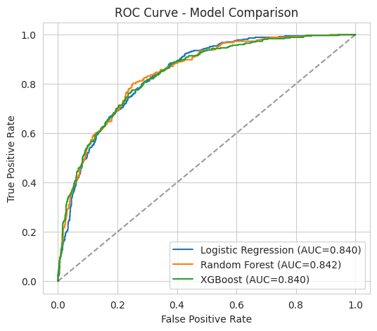

|  | accuracy | precision | recall | f1_score | roc_auc |
| --- | --- | --- | --- | --- | --- |
| Logistic Regression | 0.739 | 0.505 | 0.797 | 0.618 | 0.840 |
| Random Forest | 0.768 | 0.545 | 0.765 | 0.636 | 0.842 |
| XGBoost | 0.758 | 0.530 | 0.767 | 0.627 | 0.840 |

```python
plt.figure(figsize=(6,5))
for name, prob in roc_data.items():
    fpr, tpr, _ = roc_curve(y_test, prob)
    plt.plot(fpr, tpr, label=f"{name} (AUC={results[name]['roc_auc']:.3f})")
plt.plot([0,1],[0,1],"k--", alpha=0.4)
plt.xlabel("False Positive Rate"); plt.ylabel("True Positive Rate")
plt.title("ROC Curve - Model Comparison")
plt.legend()
plt.show()

pd.DataFrame(results).T.round(3)
```

**Model choice note:** We prioritize **Recall** for this business problem — missing a customer who is about to churn (false negative) is more costly than wrongly flagging a happy customer (false positive), since the retention team can simply skip a false alarm at low cost, but a missed churner is lost revenue.

## 6. Feature Importance & Explainability

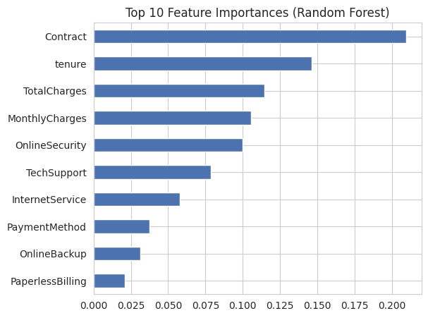

```
Contract            0.209347
tenure              0.146032
TotalCharges        0.114548
MonthlyCharges      0.105700
OnlineSecurity      0.100071
TechSupport         0.078616
InternetService     0.058028
PaymentMethod       0.037661
OnlineBackup        0.031142
PaperlessBilling    0.020760
dtype: float64
```

```python
importances = pd.Series(rf.feature_importances_, index=X.columns).sort_values(ascending=False).head(10)
plt.figure(figsize=(6,5))
importances.sort_values().plot(kind="barh", color="#4C72B0")
plt.title("Top 10 Feature Importances (Random Forest)")
plt.show()
importances
```

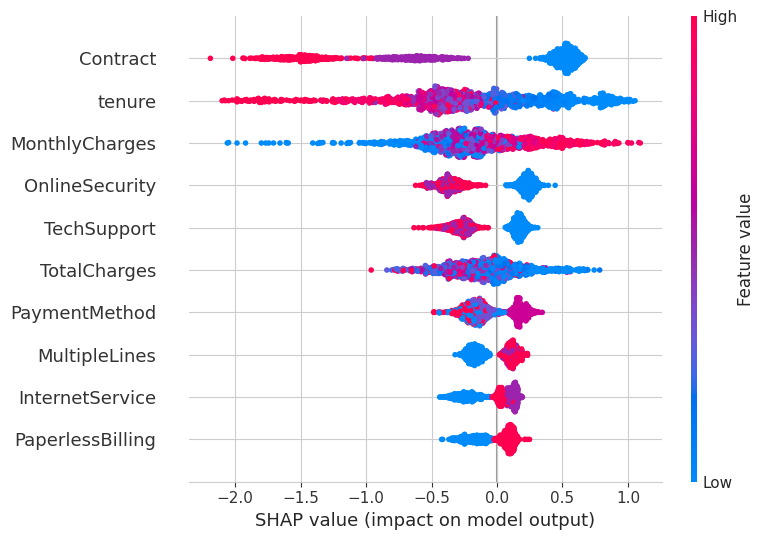

```python
explainer = shap.TreeExplainer(xgb_model)
shap_values = explainer.shap_values(X_test)
shap.summary_plot(shap_values, X_test, feature_names=X.columns.tolist(), max_display=10)
```

**Insight from SHAP:** Contract type, tenure, and monthly charges consistently show up as the strongest churn drivers across both tree-based models — this aligns with what we saw in EDA and gives the business concrete, explainable levers to act on (e.g., incentivize longer contracts, target early-tenure customers with retention offers).

## 7. Business Recommendations

Based on the analysis:

1. **Target month-to-month customers** with incentives to move to annual contracts (biggest churn driver).
2. **Focus retention efforts in the first 3–6 months** of a customer's lifecycle — churn risk is highest early on.
3. **Review fiber optic service** pricing/quality — these customers churn more than DSL users.
4. **Use the trained model** to score customers monthly and flag the top-risk segment for proactive outreach.

## 8. Save the Best Model

```python
import joblib
best_name = max(results, key=lambda k: results[k]["roc_auc"])
best_model = {"Logistic Regression": log_reg, "Random Forest": rf, "XGBoost": xgb_model}[best_name]
print("Best model by ROC-AUC:", best_name)

joblib.dump(best_model, "../outputs/best_model.pkl")
print("Model saved to outputs/best_model.pkl")
```

```
Best model by ROC-AUC: Random Forest
Model saved to outputs/best_model.pkl
```